# TidyTuesday Week 41: NCAA Women’s Basketball Tournament

joleenbelinda

2020-10-06

The TidyTuesday data this week comes from [FiveThirtyEight]{https://fivethirtyeight.com/features/louisiana-tech-was-the-uconn-of-the-80s/}.

## Useful info from the FiveThirtyEight article

We can use NCAA Tournament seeds as a proxy for team strength over time.

This doesn’t explicitly factor in how a team performs in the tournament itself, but it does measure the general quality of a team’s entire season — plus, higher seeds tend to win more in the tournament anyway.

To measure this, we awarded “seed points” in proportion to a given seed number’s expected wins in the tournament, calibrated to a 100-point scale where the No. 1 seed gets 100 points, No. 2 gets 70 points, and so forth.

## Goals for this analysis

Considering each row to be each school’s results per conference per year.

What are the average seed points (at the end of the tournament) if a school plays their first game at home compared to if they played their first game away? How has this changed over the years?

Is there a difference in the win rate if the first game is played at the home court compared to if it is played away? How has this changed over the years?

## Data Preparation

```r
library(tidyverse)
library(scales)
library(ggthemes)

theme_set(theme_pander(base_size = 50, base_family = "Roboto Condensed"))
```

```r
tuesdata <- tidytuesdayR::tt_load(2020, week = 41)
```

```
--- Compiling #TidyTuesday Information for 2020-10-06 ----
--- There is 1 file available ---
--- Starting Download ---
```

```
--- Download complete ---
```

```r
tournament <- tuesdata$tournament
```

Calculate seed points according to the table given by FiveThirtyEight.

```r
tournament_points <- tournament %>%
  mutate(seed = case_when(is.na(seed) == TRUE ~ 0,
                          TRUE ~ as.numeric(.$seed))) %>%
  mutate(points = case_when(seed == 1 ~ 100,
                            seed == 2 ~ 72.7,
                            seed == 3 ~ 54.5,
                            seed == 4 ~ 48.5,
                            seed == 5 ~ 33.3,
                            seed == 6 ~ 33.3,
                            seed == 7 ~ 27.3,
                            seed == 8 ~ 21.2,
                            seed == 9 ~ 18.2,
                            seed == 10 ~ 18.2,
                            seed == 11 ~ 18.2,
                            seed == 12 ~ 15.2,
                            seed == 13 ~ 9.09,
                            seed == 14 ~ 6.06,
                            seed == 15 ~ 3.03,
                            seed == 16 ~ 0,
                            TRUE ~ 0)) %>%
  mutate(seed_points = seed*points)

# View the data
tournament_points
```

| year | school | seed | conference | conf_w | conf_l | conf_percent | conf_place | reg_w | reg_l | reg_percent | how_qual | x1st_game_at_home | tourney_w | tourney_l | tourney_finish | full_w | full_l | full_percent | points | seed_points |
| --- | --- | --- | --- | --- | --- | --- | --- | --- | --- | --- | --- | --- | --- | --- | --- | --- | --- | --- | --- | --- |
| 1982 | Arizona St. | 4 | Western Collegiate | NA | NA | NA | - | 23 | 6 | 79.3 | at-large | Y | 1 | 1 | RSF | 24 | 7 | 77.4 | 48.50 | 194.00 |
| 1982 | Auburn | 7 | Southeastern | NA | NA | NA | - | 24 | 4 | 85.7 | at-large | N | 0 | 1 | 1st | 24 | 5 | 82.8 | 27.30 | 191.10 |
| 1982 | Cheyney | 2 | Independent | NA | NA | NA | - | 24 | 2 | 92.3 | at-large | Y | 4 | 1 | N2nd | 28 | 3 | 90.3 | 72.70 | 145.40 |
| 1982 | Clemson | 5 | Atlantic Coast | 6 | 3 | 66.7 | 4th | 20 | 11 | 64.5 | at-large | N | 0 | 1 | 1st | 20 | 12 | 62.5 | 33.30 | 166.50 |
| 1982 | Drake | 4 | Missouri Valley | NA | NA | NA | - | 26 | 6 | 81.3 | auto | Y | 2 | 1 | RF | 28 | 7 | 80.0 | 48.50 | 194.00 |
| 1982 | East Carolina | 6 | Independent | NA | NA | NA | - | 19 | 7 | 73.1 | at-large | N | 0 | 1 | 1st | 19 | 8 | 70.4 | 33.30 | 199.80 |
| 1982 | Georgia | 5 | Southeastern | NA | NA | NA | - | 21 | 8 | 72.4 | at-large | N | 0 | 1 | 1st | 21 | 9 | 70.0 | 33.30 | 166.50 |
| 1982 | Howard | 8 | Mid-Eastern | NA | NA | NA | - | 14 | 10 | 58.3 | auto | N | 0 | 1 | 1st | 14 | 11 | 56.0 | 21.20 | 169.60 |
| 1982 | Illinois | 7 | Big Ten | NA | NA | NA | - | 21 | 8 | 72.4 | at-large | N | 0 | 1 | 1st | 21 | 9 | 70.0 | 27.30 | 191.10 |
| 1982 | Jackson St. | 7 | Southwestern | NA | NA | NA | - | 28 | 7 | 80.0 | auto | N | 0 | 1 | 1st | 28 | 8 | 77.8 | 27.30 | 191.10 |

[output cut: 990 more lines]

```r
NA
```

Clean up some dirty data in the `x1st_game_at_home` variable

```r
tournament_points <- tournament_points %>%
  mutate(x1st_game_at_home = case_when(x1st_game_at_home == "Y^" ~ "Home",
                                       x1st_game_at_home == "Y" ~ "Home",
                                       x1st_game_at_home == "N" ~ "Away"))
```

## Data Visualisation

Calculate average points obtained per year, split by home/away on first game.

The scatter plot shows that prior to 1995, away games awarded higher average seed points. However, after 1995 it seemed to become a more determining factor to the number of tournaments won if the first game was played on the home court.

```r
avgPointsByYear <- tournament_points %>%
  group_by(year, x1st_game_at_home) %>%
  summarise(meanSeedPoints = mean(seed_points))
```

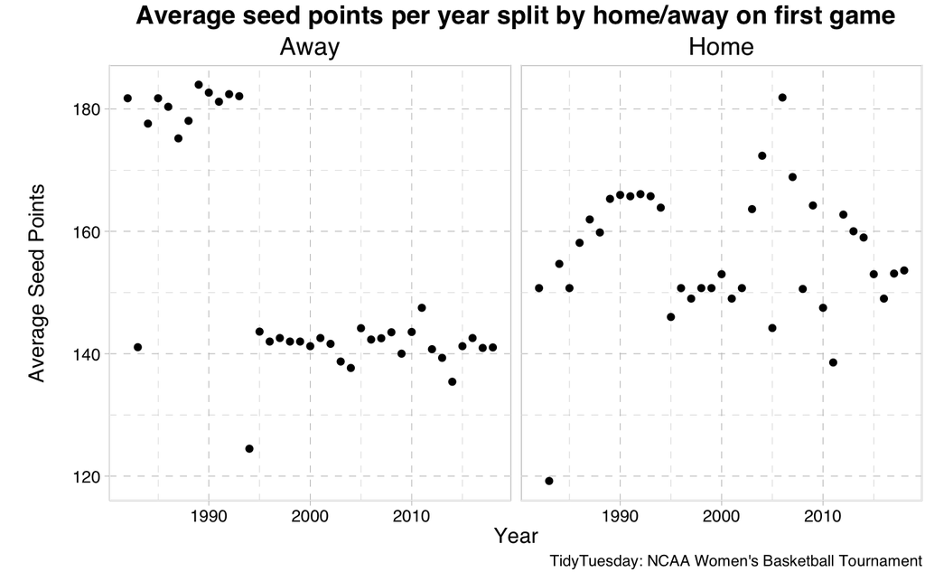

```r
# Scatter plot
ggplot(avgPointsByYear, aes(x = year, y = meanSeedPoints)) +
  geom_point() +
  facet_wrap(~ x1st_game_at_home) +
  labs(title="Average seed points per year split by home/away on first game",y="Average Seed Points", x="Year",caption="TidyTuesday: NCAA Women's Basketball Tournament") +
  theme_pander() +
  theme(strip.text.x = element_text(size = 14),
        axis.title.y = element_text(margin = margin(20, 15, 20, 15)),
        panel.background = element_rect(fill = NA, color = "black"))
```

Calulcate the win rate per year split by home/away on first game.

The scatter plot shows that playing the first game at home has a big impact on the overall win rate in tournaments. There is an improvement in the win rate around 2005-2010 for first games played away.

```r
TourneyWinRate <- tournament_points %>%
  group_by(year, x1st_game_at_home) %>%
  summarise(winRate = sum(tourney_w)/(sum(tourney_w)+sum(tourney_l)))
```

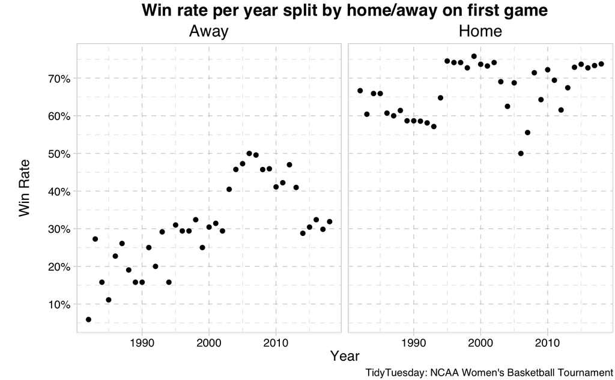

```r
# Barplot
ggplot(TourneyWinRate, aes(x = year, y = winRate)) +
  geom_point() +
  facet_wrap(~ x1st_game_at_home) +
  scale_y_continuous(labels = label_percent(accuracy = 1), n.breaks = 8) +
  labs(title="Win rate per year split by home/away on first game",y="Win Rate", x="Year",caption="TidyTuesday: NCAA Women's Basketball Tournament") +
  theme_pander() +
  theme(strip.text.x = element_text(size = 14),
        axis.title.y = element_text(margin = margin(20, 15, 20, 15)),
        panel.background = element_rect(fill = NA, color = "black"))
```